# Sea Crossings Chapters 3 and 4

Bailey Baumann

August 2017

*Please see http://spatial.usc.edu/index.php/m-s-in-gist-theses/ for the full thesis.*

# Chapter 3 Model Design

The research question for this study is: “How can we find places where the environment created opportunities for early sea crossings.” The working hypothesis is that a data-rich, geographically explicit agent-based model could help Mediterranean archaeologists find these places. An agent-based model can allow archaeologists to formulate and test theories about the ways past environments created opportunities for sea crossings. Accordingly, the purpose of this research was to determine how such a model could be designed.

## 3.1. Required Software

This model was written on Mac OS X 10.12.3. The language R (version 3.3.3) and software NetLogo (version 6.0.1) were used to create this model. R is a programming language and software environment used for statistical analysis and visualization. Its flexibility lends it to a wide range of applications, including spatial science. R is especially useful for managing large datasets and repeated tasks, which was an important consideration for this project given its temporal and spatial scale. NetLogo is the agent-based software used in this project. Its versatility, the abundance of its documentation and the quality of its visualizations made it a good fit. Often the inner workings of agent-based models can be a black box to researchers trying to understand them. There is input and output, and what occurs between must be inferred. NetLogo’s visualizations and its monitors, which update as the model runs, help mitigate this problem. The use of R and NetLogo also make this project easier to share and reproduce. R and NetLogo are both open source and freely available online. The data and code used in this project have been made available on GitHub (Baumann 2017a). The NetLogo models used in this study are both available on Modeling Commons (Baumann 2017b). An R Markdown HTML document allows code chunks and plots generated from them to be included within a text. R Markdown versions of Chapters 3 and 4 have been created and posted to the GitHub repository for this project as well. Code chunks included throughout the remainder of this document match those that appear in the R Markdown versions of these chapters. Code Chunk 1 lists the main R packages used in this project. Among these, one stands out as particularly important. The package “raster” allows for the manipulation of spatial data that is used to determine the changing environmental conditions in the model cells.

```
install.packages('raster')
install.packages('rdrop2')
install.packages('gdalUtils')
install.packages('rgdal')
install.packages('proj4')
install.packages('gdistance')
install.packages('RColorBrewer')
install.packages('psych')
```

Code Chunk 1: R Packages Needed to Run This Model (R)

## 3.2. Conceptual Model

A geographically explicit agent-based model was designed to show where environmental pressures could have created opportunities for sea crossings in the Middle to Late Pleistocene Mediterranean. This model involves recreating past landscapes and representing agent movement over those landscapes based on spatially and temporally varying levels of cost as well as temporally varying levels of motivation. Below is the conceptual model diagram that guided the design process. Environmental factors, such as slope, wind, and vegetation were processed in R to generate a cost and motivation value for each cell in one of the reconstructed environments. Agent movement over these reconstructed environments was modeled in NetLogo. The results of this model can be read in terms of the agent distribution after a run.

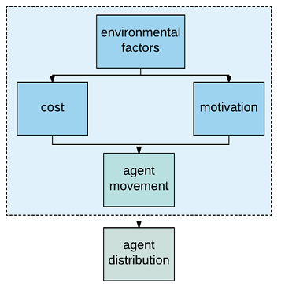

Figure 1: Conceptual Model Diagram

For land cells, the cost of moving from one cell to the next is calculated in terms of slope. For sea cells, the cost of moving to the next cell is represented by wind cost. In order to keep this model as straightforward and easy to run as possible, there are no directional variables. In this model, higher slope indicates more difficult terrain and higher winds indicate choppier seas. This model focuses on the role of decreasing vegetation as a driver of migration.

Agents make decisions about how to move across the modeled landscapes based on spatially and temporally varying levels of motivation and cost. In this model, an agent represents one person or group of people. Rather than attempting to precisely estimate the number of people and size and location of their groups, this model simply works with 100 agents that begin at random points within the study area. This was a large enough number to test agent responses to different parts of the study area over a 1,000 or even 500 year run. Moreover, the use of 100 agents makes it easier to translate readings from monitors into percentages (e.g. Only 3% of agents select high cost cells during the conditions of this time slice).

### 3.2.1. ODD Protocol of the Sea Crossings Model

A standard way to systematically describe the design of an agent-based model is the Overview, Design concepts, and Details (ODD) protocol, which was first published in 2006 (Grimm et al. 2006). This model is described below using guidance from the updated ODD (Grimm et al. 2010) which outlines the required components of the protocol. These components include descriptions of the dimensions of variables within the modeled environment. They also describe the agents themselves and how they function within this system. While code chunks are helpful to those familiar with the programming languages used in a particular study, the ODD is a better tool for describing a model to developers who prefer other programming languages or to people who prefer not to read code at all.

*Overview*

**Purpose:** This model shows that an agent-based model can be used to answer the question, “How can we find places where the environment created opportunities for early sea crossings.” In doing so it operationalizes a revisionist conceptual model in which the sea was less of a barrier and more of a facilitator for early human migration in the Pleistocene Mediterranean, setting it apart from other, more terrestrial models of Pleistocene migration through the region.

**Entities:** Agents representing migrating people or groups of people (100 during each model run) and grid cells.

**State variables:** The cell variables are land.or.sea, cost, motivation, boundary, difference, times.here.

**Scales:** Temporal scale is 769,000 years. In the full model, the temporal resolution is 1 year with environmental (cell variable) changes every 1,000 years. Cell resolution is 34 km X 34 km. Model environment is 82 x 125 cells.

**Process and scheduling:** If in the set of neighboring cells, there exist cells for which motivation is greater than cost, the agent will move to the cell in which the difference between motivation and cost is the greatest. In other words, the agents must determine whether they have enough reason to move to a neighboring cell to make it worth the effort it would take to get there. If competition is enabled, agents will not move to cells that are already occupied by more than the allowed number of agents (adjustable by slider). Difference and times.here are updated every tick. Land.or.sea, cost, motivation, and boundary are updated every 1,000 years. Time is represented through discrete steps (ticks). A run of this model requires that the agents move over one environment for a set number of ticks (representing years). In the full model, a run takes 1,000 years or ticks and there are 769 runs for the entire time range included.

*Design Concepts*

**Basic principles:** In this model, the sea is a facilitator and not a barrier for early human migration. Higher slope indicates steeper terrain, which is more costly to traverse. Likewise, higher winds indicate choppier seas, which is more costly to cross. The main driver (motivation) is decrease in vegetation as indicated by levels of Saharan dust measured from a sea core are which are indicative of aridity at different time steps. These measures are used as proxies for general environmental pressures for migration.

**Emergence:** In the test run described in Chapter 4, agents appeared to cluster in certain sections of the modeled environment. This is an encouraging sign that a model like this might be generating patterns that were not directly programmed. However, no definitive claims can be made at this time.

**Adaptation:** Indirect adaptation can be modeled through sea crossings, which happen because of chance and immediate environmental conditions. Agents can cross the sea if the cost of crossing the land in their immediate environment is greater than the cost of crossing the sea and the amount of motivation in that time slice makes the cost of crossing the sea worth it.

**Objectives:** Agents want to be in the cell with the greatest difference between motivation and cost. At times when motivation is low or equal to cost, they will not move at all. At times when motivation is higher, they will have more reason to traverse cells with higher costs (either due to slope or wind speed).

**Learning:** Agents cannot learn or remember.

**Prediction:** There is minimal prediction. Agent decision-making horizons are temporally limited to the current tick (year) and spatially limited to the surrounding four cells.

**Sensing:** Agents are able to examine four proximal cells (rook case) and determine which one has the greatest difference between cost (slope or wind speed) and motivation (vegetation level, uniform throughout the whole environment for each time step).

**Interaction:** If competition is enabled, agents will not be able to move to a cell that has more than the allowed number of agents.

**Stochasticity:** The starting points of the agents are randomly determined. At 781,000 ybp (the lower temporal limit of the model) humans could have been present in Europe, not just in Africa and the Levant. Allowing agents to begin at any point in the model allows us to better understand how people would have moved about the environment as a whole and it does not artificially limit people to starting points within Africa.

**Collectives:** Agents can represent one person or groups of people. However, these agents will still operate in this environment the same way. Cooperation isn’t represented in this model, though it might be in future versions (for example larger vessels would require more people to build and operate).

**Observation:** The results of dummy data and real data runs are interpreted using the distribution of agents on the NetLogo interface and the levels of key monitors indicating the number of agents on land and sea as well as the number of agents on high cost cells. Agents hatch trails so their paths can be traced as the model runs. Though not used in this study, the cell variable, times.here, can be exported using the GIS extension and examined as a heat map.

*Details*

**Initialization:** At years=0, the cells have been set up according to the land.or.sea, cost, motivation, and boundary variables for that time slice. Additionally, 100 agents have been randomly scattered throughout the environment. Times.here is 0. Initialization is always the same. Currently, the model cannot remember agent locations or cell variables from previous time slice runs.

**Input data:** The patch variables land.or.sea, cost, motivation, and boundary are imported using the GIS extension and four ASCII files per time slice or run.

**Submodels:** This model contains 769 time slices for 769 model runs, each meant to be run for 1000 years (ticks). Thus the agent decision making scheme can be run in 769 different environments.

## 3.3. Agent Decision-Making Algorithm

Taking after Bettinger et al. (2015) and Grimm et al. (2005), as described in Section 2.2 above, this model has at its core a decision-making algorithm. There is a simple set of rules that the agents must follow when deciding how they are going to move around the study area. These rules are based on the concept of cost distance and the Principle of Least Effort (Zipf 1949). If in the set of neighboring cells, there exist cells for which motivation is greater than cost, the agent will move to the cell in which the difference between motivation and cost is the greatest. In other words, the agents must determine whether they have enough reason to move to a neighboring cell to make it worth the effort it would take to get there. If competition is enabled, agents will not move to cells that are already occupied by more than the allowed number of agents (adjustable by slider). The decision-making scheme of the agents is summarized in Figure 2 below.

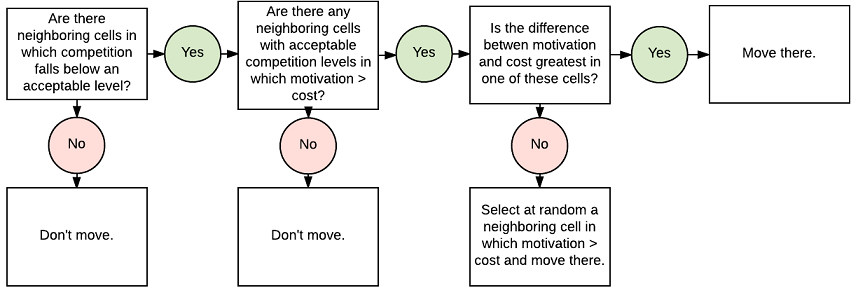

Figure 2: Agent Decision-Making Algorithm

This decision-making algorithm was then translated into NetLogo code. Code Chunk 2 shows the NetLogo code that controls how the agents move considering different levels of competition and different coefficients for cost and motivation. The hatch-trails procedure allows each agent to leave a visual path in the interface. However, for more systematic analysis of the distribution of the agents after a run, the times.here patch variable can be used. There are two separate move-persons procedures in Code Chunk 2. One is run if competition is enabled and one is run if competition is not enabled. The maximum number of agents per cell can be set before the run using a slider in the interface.

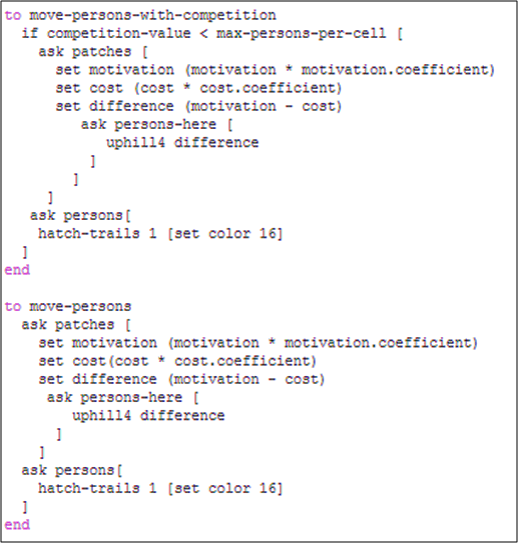

Code Chunk 2: NetLogo Move Persons Procedure (NetLogo)

### 3.3.1. Testing the Agent Decision-Making Algorithm

To test the decision-making algorithm and ensure that it was correctly translated into NetLogo code, a version of the model was created to run on dummy data. It is available on Modelling Commons (Baumann 2017b). In the dummy version of the model, there are an even number of land and sea cells and they are randomly assigned. The motivation for all cells is set using a slider in the interface. Cost is randomly assigned values as well, and a histogram in the interface can be used to ensure that roughly the same number of cells are assigned each cost value. However, range of cost and motivation values is kept the same as it is in the real version of the model (values: 1-5, coefficients: 1-3). The randomness in this dummy model allowed it to be used as a control. This dummy model was used to confirm that nothing was accidentally coded into the model that would force agents to cluster in one part of the study area or favor sea cells over land cells. This way, when the model was run with real data, this kind of emergence could be attributed to the data rather than the model itself.

This dummy model was used for initial sensitivity analysis, to make sure the model functioned as it should before the real data were introduced. The sensitivity analysis (SA) was designed as a compromise between one at a time (OAT) SA and global SA. While global sensitivity analysis is more comprehensive, OAT is less computationally rigorous. The worksheet used for the sensitivity analysis of this model can be found on the GitHub repository for this study (Baumann 2017a). Figure 4 shows an image of the dummy model interface after a run. The blue cells represent sea and the green cells represent land. The red points are trails agents left behind after moving over a cell.

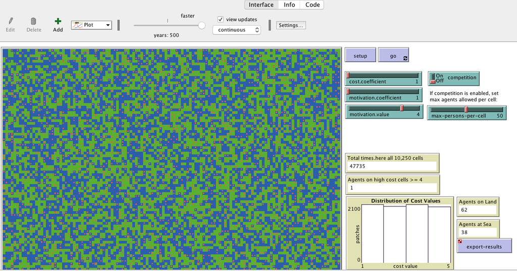

Figure 4: Dummy Model Interface after a Run

In the sensitivity analysis, first, every combination of cost.coefficient, motivation.coefficient, and motivation.value were run. During these runs, competition was left off. Next, every value of max.persons.per.cell was tested while the other values were left at 1. To complete all combinations, there were a total of 145 runs and the values of the monitors were recorded after each run.

For the most part, the distribution of agents over land cells and sea cells was about even at the beginning and ends of runs. This is means that any major difference in the number of agents on sea cells in the real model is more likely to be caused by the data than by the NetLogo code itself. As expected, increasing the number of agents allowed per cell increased the amount of movement during the runs. Having monitors that changed in the interface during the runs proved especially useful, especially since increasing the cost coefficient increased the number of high cost cells in general. Interestingly, most agent movement seemed to occur at the beginning of the runs. This was the justification for reducing the number of ticks for a dummy data run to 500 ticks instead of 1,000 after an error began to occur in the interface. As a result, in the dummy model, 1 tick is equivalent to 2 years. This error does not occur in the real model, but it was observed over the course of this study that the longer NetLogo was run, and the more complex the input became, the more likely interface errors were to occur.

In general, the expectation was that the greater motivation was relative to cost, the more movement there would be over the modeled environment and the more agents would appear on high cost cells. This mostly held true: increasing motivation (either the coefficient or the value itself) did increase movement over the modeled environment. However an important find was that raising the cost coefficient kept agents moving for a longer period of time than just raising the motivation coefficient did. This is likely because of the randomness with which cost cells were distributed in the model. There are likely many instances where low cost cells are directly situated next to high cost cells. These situations are less frequent in the real model. These initial runs with dummy data indicate how important local variation in cost can be when understanding the effects of a large regional driver like decreasing vegetation. Therefore, the next step in developing this model was devising a reliable way to prepare reconstructed environments over which to model agent movement.

## 3.4. Modeled Environment

The elevation raster used in this study is the ETOPO1, a one arc-minute Global Relief Model that includes both bathymetric and topographic data (Amante and Eakins 2009). This dataset, acquired in the (unprojected) WGS 1984 datum, was used to establish the raster framework for the model. Because of the size and location of the study area, as well as the types of spatial questions this model seeks to explore, a compromise global projection, the Winkel Tripel, was required. The Winkel Tripel attempts to minimize the distortion of shapes, areas, and distances. The National Geographic Society has used the Winkel Tripel in place of the Robinson projection since the late 1990s (Esri 2016).

The map was examined, projected, and cropped in ArcMap. This version of the map is available in the GitHub repository for this study and is labeled “raster0” (Baumann 2017a). Then the map was imported into R. With accessibility in mind, the resolution of the model was deliberately lowered to 34 km x 34 km so that the model could be run on personal computers without encountering Java heap size errors. Aggregating the data for NetLogo meant agents were considering larger sections of the study area when making their decisions. Though not preferred, it did not harm the overall ability of the model to indicate large regional trends in agent distribution.

Code Chunk 3 shows how this raster was imported, aggregated, plotted, and examined in R. While the raster was already projected in ArcMap, it was necessary to identify the projection of this raster in R. The aggregate function of the R raster package was used to reduce the cell resolution of the modeled environments to approximately 34km x 34km. This level of aggregation was selected by trial and error. Different environments were loaded into the NetLogo model until one could be found that both loaded reasonably well and faithfully represented the shapes of the landforms in the study area. The projected, aggregated study area with modern sea levels is shown in Figure 5 below.

```
require(raster)
require(rgdal)
require(rdrop2)
require(gdalUtils)
require(proj4)
require(psych)

#import & project base raster
base.raster <- raster("~/Desktop/seacrossings/raster0")
projection(base.raster) <- "+proj=wintri"
raster0 <-aggregate(base.raster, fact=20, fun=mean, expand=FALSE)

#examine then plot the base raster
summary(raster0)
breakpoints <- c(-4966.0925, -1, 1, 2643.2900)
colors <- c("blue", "green")
plot(raster0, breaks=breakpoints, col=colors)

#determine the world settings and transformation for NetLogo
ncell(raster0)
nrow(raster0)
ncol(raster0)
res(raster0)
nl.trans <- c(xmin(raster0), xmax(raster0), ymin(raster0), ymax(raster0))
```

Code Chunk 3: Import, Aggregate, Plot, and Examine Base Raster (R)

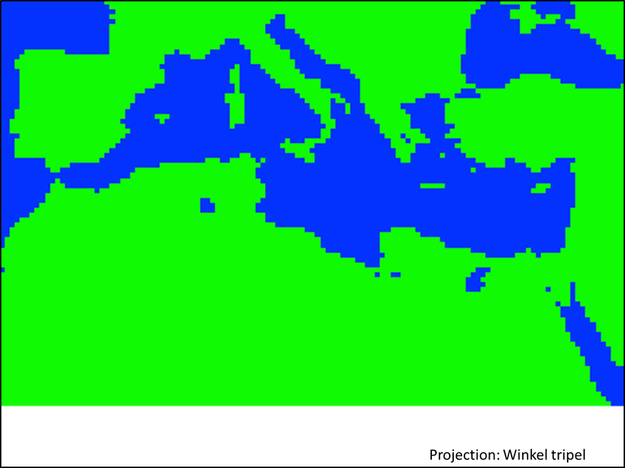

Figure 5: Aggregated Study Area with Modern Sea Levels

The NetLogo settings were configured so that the world was finite and did not wrap around itself. This was done to keep agents from being unrealistically bound to the study area or from ending up at one edge of the model after wandering off the opposite edge (the default setting in NetLogo). Instead, a procedure called remove-persons was written so that agents would disappear (or in NetLogo language, “die”) if they reached an edge. A procedure called replace-persons was written so that an agent would then appear at a random point in the model to replace the agent who left the modeled environment. These procedures can be found in the NetLogo models posted on Modeling Commons and GitHub (Baumann 2017a; Baumann 2017b)

### 3.4.1. Reconstructing Past Environments

When covering such a large period, especially in the Mediterranean, it is important to account for varying environments so that the decisions agents make based on environmental pressures can be shown against the corresponding environments at those times. By dividing the temporal range of 769,000 years into 1,000 year slices, a collection of 769 raster stacks was created with each stack representing the environment for a specific 1,000 year slice. The next step was to find a driver and a landscape for each time slice, in other words, a dust level and a sea level.

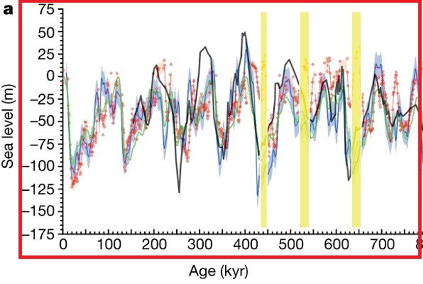

Figure 6: Digitized Portion of Rohling et al. (2014) Sea Levels Chart

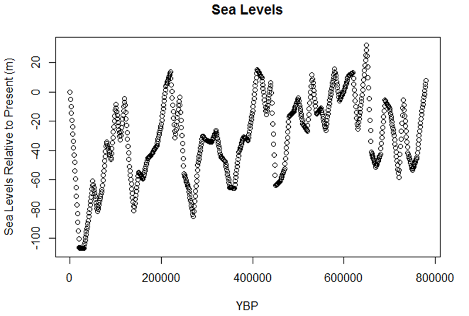

Figure 7: Sea Levels Used in this Model. Data: Rohling et al. 2014

While past sea levels alone have been used to map estimates of exposed land (e.g. Voris 2000), additional criteria would be needed to more precisely reconstruct coastlines, especially in the Aegean. Sea levels alone cannot be used to determine which islands were once connected to land. For that, subsidence rates (Lykousis 2009) would need to be accounted for. Accordingly, while this model only accounts for changes in past sea levels at each time step, the work of those like Lykousis (2009) and Lambeck et al. (2011) should be considered when examining the model’s results. For example, it is possible that the Cyclades were connected to the mainland at times during the Pleistocene, though this model did not show it.

In light of the literature described in Section 1.2, decrease in vegetation is conceptually the main driver in the model. Since no readily available data on vegetation over the temporal range of the model is available, Aeolian dust levels, as calculated by Larrasoana (2003) and discussed above, were used to indicate temporally varying levels of regional environmental pressures serving as motivation for migration. These data indicate levels of aridity in the Sahara. They can be read as a proxy for vegetation and they also speak to larger climatic trends in the region. Therefore these data do not vary spatially. They indicate the overall environmental pressures for migration in the region during a time slice.

These data were already in a tabular format so no digitizing was necessary. However one dust level was needed for every 1,000 years (the data had a temporal resolution of 400 years). Because a similar data wrangling process was required for both sea and vegetation levels, a test was devised to determine whether this process was faster in R or in Excel. The process of preparing sea level data as described above was saved in an Excel Workbook which can be found on the GitHub repository for this model (Baumann 2017a). The process of similarly preparing vegetation data in R is shown in Section 3.5.4. The R method was faster for such a large dataset. A calculation could be applied to the entire dataset at once without the need for highlighting, copying and pasting, or even pivot tables. The dust levels from Larrasoana (2003) are shown in Figure 8 below.

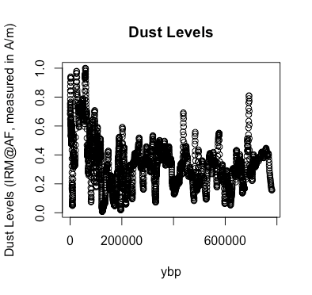

Figure 8: Dust Levels (Vegetation Proxy & Main Driver). Data: Larrasoana et al. 2003

To account for the cost of moving over sea cells, a wind speed dataset was acquired and built into the model. As summarized earlier, previous work has shown how present-day wind patterns might be used in simulation models in place of past wind data (Murray 1987; Leidwanger 2013). As shown in Figure 9, The Modern Era-Retrospective Analysis for Research and Applications (MEERA) 100 m layer from the Global Wind Atlas provides mean wind speeds aggregated from simulations spanning 1979 - 2013 (DTU Wind Energy, 2017). This was an image that was georeferenced in ArcMap and then converted to a single-band raster before being imported into R where it was aligned and resampled to match the dimensions and resolution of the base raster.

[figure not shown]

Figure 9: MEERA 100m Layer of the Global Wind Atlas

The Wind and Wave Atlas of the Mediterranean Sea is another dataset that might have been used in this model. It provides aggregated wind and wave data for the Mediterranean and it uses samples spanning a 10-year period (Cavaleri 2005). However, the continuous surface model of the Global Wind Atlas was easier to adapt to this model than the vectors provided by the Wind and Wave Atlas.

## 3.5. Raster Layers

Four ASCII files are prepared in R to be run in NetLogo for each time slice. The first ASCII file indicates whether each cell is a land cell (1) or a sea cell (0). The second indicates the cost to traverse each cell (values range from 1-5). The third indicates the motivation for all cells during that particular time slice (values range from 1-5, but are spatially constant in each time slice). The last ASCII file indicates whether the cell is on the edge of the modeled environment (1 or 0).

To capture the range of environments possible, the time slices with the lowest, median, and highest sea levels (LSL, MSL, HSL) during the Middle to Late Pleistocene were the focus when designing the model. The code below describes how the ASCII files for these time slices were generated, and the same method can be used to generate ASCII files for any of the other time slices in this study.

The raster package in R allows related rasters to be stacked on top of one another so that cell values in one raster can be calculated based on the values of corresponding cells in related rasters. Layers in a raster stack can be called for different functions using their position within that raster stack. This is analogous to the way components in a vector are handled. Figure 10 shows the components of the raster stacks used for spatial analysis in R, and for reading different environments into NetLogo. Layers within a raster stack are indicated by their position.

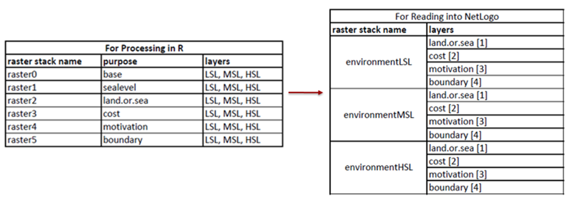

Figure 10: Raster Layer Names

### 3.5.1. Raster 1 Sea Level

In the code chunk below, the base raster is reclassified using past sea levels in order to approximate the appropriate paleocoastlines. These sea levels come from the Rohling et al. (2014) data set after the data preparation described in Section 3.4.1.

```
#raster1 (partial)
#sealevel
raster1LSL <- (raster0 - 107.02)
raster1MSL <- (raster0 - 30.84)
raster1HSL <- (raster0 + 31.67)
```

Code Chunk 4: Raster 1 Sea Levels (R)

### 3.5.2. Raster 2 Land or Sea

Once the different sea levels can have been accounted for, the rasters from the previous step can again be reclassified to create new layers that identify all cells as either land (1) or sea (0). To do this a three column from-to-becomes matrix is created and then used to identify which range of elevations should be designated as land and which should be designated as sea. For example, in Code Chunk 5, six values are concatenated and then converted into a three column matrix. The first value is the lowest elevation that could be considered sea. The second value is the highest elevation that could be considered sea. The third value “0” is assigned to any cells that have elevations within this range. Next is the lowest elevation that could be considered land and then the highest elevation which could be considered land. Elevations within this range are assigned a “1.” A lower sea level and a higher elevation than are likely to be found in any of the possible environments are used in this matrix as a precaution. This way, if any cells have an elevation that does not fit into the matrix, they will receive an NA value, and NetLogo can encounter errors when it is asked to perform a mathematical operation on a non-number. This check prevents NA values.

```
#raster2 (partial)
#land.or.sea
m <- c(-6000,-1,0, -1,4000,1)
rclmat<-matrix(m, ncol=3, byrow=TRUE)
raster2LSL <- reclassify(raster1LSL, rclmat)
raster2MSL <- reclassify(raster1MSL, rclmat)
raster2HSL <- reclassify(raster1HSL, rclmat)
```

Code Chunk 5: Raster 2 Land or Sea (R)

### 3.5.3. Raster 3 Sea Cost (Wind) and Land Cost (Slope)

This next step requires the wind layer to be imported and aligned to the base raster. The resolution of the wind data was 100m, but wind raster had to be resampled so that it had the same number of cells as the base raster. Nearest neighbor (“ngb” in Code Chunk 6) is the resampling method used. A reclassification matrix is then used to sort the wind raster values into five classes. As mentioned above, five classes were used for slope, wind, and dust levels. These classes were manually set using histograms of each data set. The values in the reclassification matrix in Code Chunk 6 correspond to values from the single-band, grayscale image, but the actual range of values for the study area is 4-8 m/s.

Next, slope is calculated using the terrain function from the raster package. The unit used is degrees and only four neighbors (rook case) are used in the calculation. The NetLogo model is also limited to four neighbors to allow it to be more easily run and understood. However, future versions of the model have the option of eight neighbors both at this step and within the NetLogo move-persons procedure.

For cost and motivation to be comparable and then simultaneously scalable in the weighted versions of the model, wind, slope, and vegetation all needed to be sorted into the same number of classes. To do this, histograms were created in R for each dataset. The distribution of the data was examined and five classes were selected because it was a low number that still accounted for the variety in the data.

Lastly, a function is used to assign a slope value to sea cells and a land value to raster cells. Because these raster layers are called like vectors, ifelse must be used rather than if else. Code Chunk 6 shows the process of assigning wind and slope costs to the cost rasters.

```
#raster3 (partial)
#land cost (slope) & sea cost (wind)

#import windraster
require(raster)
windraster <- raster("~/Desktop/seacrossings/windraster")
projection(windraster) <- "+proj=wintri"
alignExtent(windraster, raster0, snap= "near")
windraster.resampled <- resample(windraster, raster0, method ="ngb")

#classify windraster
m.wind <- c(0, 42, 1, 42, 96, 2, 96, 163, 3, 163, 222, 4, 222, 250, 5)
rclmat.wind <- matrix(m.wind, ncol =3, byrow= TRUE)
classified.wind <- reclassify(windraster.resampled, rclmat.wind)

#calculate slope
raster3LSL0 <- terrain(raster1MSL, opt='slope', unit="degrees", neighbors=4)
raster3MSL0 <- terrain(raster1MSL, opt='slope', unit="degrees", neighbors=4)
raster3HSL0 <- terrain(raster1MSL, opt='slope', unit="degrees", neighbors=4)

#remove NAs
raster3LSL0[is.na(raster3LSL0)] <- 0
raster3MSL0[is.na(raster3MSL0)] <- 0
raster3HSL0[is.na(raster3HSL0)] <- 0

#classify slope
m.slope <- c(0, 0.5, 1, 0.5, 1.5, 2, 1.5, 2.5, 3, 2.5, 3, 4, 3, 4.5, 5 )
rclmat.slope <- matrix(m.slope, ncol =3, byrow= TRUE)
raster3LSL0c <- reclassify(raster3LSL0, rclmat.slope)
raster3MSL0c <- reclassify(raster3MSL0, rclmat.slope)
raster3HSL0c <- reclassify(raster3HSL0, rclmat.slope)

#assign slope or wind
costLSL <-stack(raster2LSL, raster3LSL0c, classified.wind)
costMSL <-stack(raster2MSL, raster3MSL0c, classified.wind)
costHSL <-stack(raster2HSL, raster3HSL0c, classified.wind)

raster3LSL <- calc(costLSL, fun= function(costLSL)
  ifelse((costLSL[1] =1), (raster3LSL <- costLSL[2]), (raster3LSL <- costLSL[3])))

raster3MSL <- calc(costMSL, fun= function(costMSL)
  ifelse((costMSL[1] =1), (raster3MSL <- costMSL[2]), (raster3MSL <- costMSL[3])))

raster3HSL <- calc(costHSL, fun= function(costHSL)
  ifelse((costHSL[1] =1), (raster3HSL <- costHSL[2]), (raster3HSL <- costHSL[3])))
```

Code Chunk 6: Raster 3 Cost (R)

### 3.5.4. Raster 4 Motivation

Code Chunk 7 shows how the vegetation proxy values (Aeolian dust levels from Larrasoana et al. 2003) are imported and processed. Unneeded data are removed, NA values are omitted, and the data are aggregated temporally so there are only values every 1,000 years. (The original data had a resolution of 400 years.) The data are then grouped into five classes. Five indicates a lot of dust, suggesting greater aridity, lower vegetation, and therefore high regional pressures for migration. One indicates a low level of dust, a high level of vegetation and much less motivation to move. The motivation level will be the same for all cells in a time slice as these values are indicative of broad environmental trends at each time period.

```
# raster4
#motivation (vegetation)

#import data
larrasoana2003 <- read.csv("larrasoana2003.csv", header=TRUE)

#remove data later than the middle to late pleistocene
mlpleist.na<-larrasoana2003[!(larrasoana2003$Age..kyr.>781),]

#remove any na values
mlpleist <- na.omit(mlpleist.na)

#convert from kyr to yr
dust <- mlpleist$IRM.0.9.AF.120mT..A.m.
dust.kyr <- mlpleist$Age..kyr.
dust.yr <- (dust.kyr * 1000)
dust.yr.trunc <- trunc(dust.yr)

#limit significant digits - we only need values every 1,000 years
dust.round <-ifelse((dust.yr.trunc <= 1000), 1000,
                    ifelse((dust.yr.trunc >1000 & dust.yr.trunc <= 10000),
                           signif(dust.yr.trunc, digits=1),
                           ifelse((dust.yr.trunc >10000 & dust.yr.trunc <= 100000),
                                  signif(dust.yr.trunc, digits=2),
                                  signif(dust.yr.trunc, digits=3))))

#aggreage dust measurements
dust.df <- data.frame(dust.round, dust)
options(scipen=10)
dust.agg <- aggregate(dust.df, by= list(dust.df$dust.round), FUN=mean, na.action= na.omit)

#sort data into classes 1-5
#level 5 vegetation = a lot of dust, therefore, regionally, a lot of pressure to move
#level 1 vegetation = not that much dust, not that much reason to move
levels.matrix <- matrix(c(0, .2, 1,   .2, .4, 2,   .4, .6, 3,   .6, .8, 4,   .8, 1, 5),
                        nrow= 5, ncol=3, byrow=TRUE)
levels.df <- as.data.frame(levels.matrix)

dust.levels <- transform(dust.agg, Type=levels.df$V3[findInterval(dust, levels.df$V1)])

#reclassify raster using vegetation data
LSL.m.veg <- c(1, 4, 0, 0)
LSL.rclmat.veg <- matrix(LSL.m.veg, ncol= 2, byrow= TRUE)
raster4LSL <-reclassify(raster2LSL, LSL.rclmat.veg)

#HSL and MSL have same dust level so we can make one reclassification matrix for both
MHSL.m.veg <-c(1, 2, 0, 0)
MHSL.rclmat.veg <-matrix(MHSL.m.veg, ncol= 2, byrow= TRUE)
raster4MSL <- reclassify(raster2MSL, MHSL.rclmat.veg)
raster4HSL <- reclassify(raster2HSL, MHSL.rclmat.veg)
```

Code Chunk 7: Raster 4 Motivation (R)

### 3.5.5. Raster 5 Identify Boundaries of Study Area

As mentioned earlier, NetLogo procedures were written to remove and replace agents that wander to an edge of the study area. They were written so that agents would not be artificially bound to the study area but also so that there could be the same number of agents within the study area at every tick in the run. This section of R code creates raster layers that indicate whether a cell is a boundary cell (1) or not (0). Because there are 125 columns and 82 rows in every raster, it is possible to identify cells that should receive a boundary value (1) based on their location.

```
#raster5 (partial)
#boudary
require(raster)
edge.cells <- c(cellFromRow(raster0, 1), cellFromRow(raster0, 82),
                cellFromCol(raster0, 1), cellFromCol(raster0, 125))
raster5 <-raster0
raster5[] <- 0
raster5[edge.cells] <- 1
```

Code Chunk 8: Raster 5 Boundary (R)

### 3.5.6. Compile and Export Environments

The code below was used to stack these layers into environments. A different environment is needed for each time slice. However, Raster 5 is the same for every run because the boundary cells are always in the same place. The writeRaster function creates a separate ASCII file for each layer in the environment raster stack and distinguishes between them by adding “_1“,”_2“,”_3“, or”_4" after the rest of the environment name.

```
#save rasters as ascii files for gis extension
writeRaster(environmentLSL, filename= "environmentLSL.asc", bylayer=TRUE)
writeRaster(environmentMSL, filename= "environmentMSL.asc", bylayer=TRUE)
writeRaster(environmentHSL, filename= "environmentHSL.asc", bylayer=TRUE)
```

Code Chunk 9: Stack and Export Environments (R)

### 3.5.7. Import Environments into NetLogo for Setup

The NetLogo GIS extension was used to import these rasters into NetLogo. After the ASCII files were loaded into NetLogo, the set-patch-values procedure converted each of these to different cell (or “patch”) variables. Land.or.sea is used to tell the agents whether they are on land or sea cells. The values from the cost and motivation variables are used in the move-persons procedure (Code Chunk 2). The boundary variable is used to remove and replace agents when they move too close to the edge of the modeled environment. The gis:apply-raster command is used here instead of the gis:raster-sample command. While both are suggested in the GIS General Examples (Wilensky 2017), gis:raster-sample produced a not real number (NaN) error.

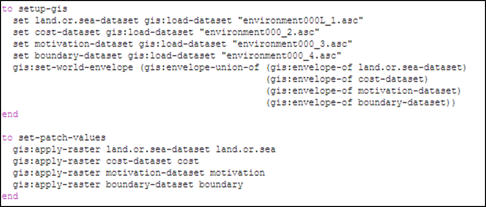

Code Chunk 10: Import Environments into NetLogo (NetLogo)

This chapter described how agents’ decision-making scheme was designed and tested. It also described the process for creating the reconstructed environments over which the agents moved. The next step was to bring everything together and test how the model worked with real data.

# Chapter 4 Results and Future Directions

The preliminary results of a test run with Low Sea Level data are discussed below. These results show that a data-rich geographically explicit model built using the process detailed above can produce patterns in the distribution of agents. A model developed using this method can be used to formulate and test theories about the ways past environments created opportunities for sea crossings. This chapter also discusses the roads not taken in the development of this model which future developers might explore when trying to understand different aspects of this system.

Before proceeding with analysis of the model results, it should be reiterated that this kind of model, like much of archaeological spatial analysis, should only be “weakly constrained by surviving control data” (Hazelwood and Steele 2004, 673). The archaeological record of this activity is especially incomplete and damaged. Care should be taken to avoid overfitting this model to the archaeological record. Additionally, because this model is so complex, it is better used to inform our understanding of the system being represented than to strongly predict behavior of past people.

## 4.1. Preliminary LSL Results and Face Validation

Figure 11 shows the NetLogo interface after a 1,000 tick or year run of the model with the ASCII files for the environment with the lowest sea level. Red dots indicate where the agents landed during the run. They can be read like a dot density map. While the data appeared to load correctly (there were no errors and the model ran all the way through 1,000 ticks), the interface behaved strangely. It shows all cells as blue instead of some green (which indicates a difference between land and sea cells). This was a pattern throughout the modeling process. The longer the model ran and the more complex the input data were, the more likely interface issues became. Nevertheless, some emergence is still visible in this interface.

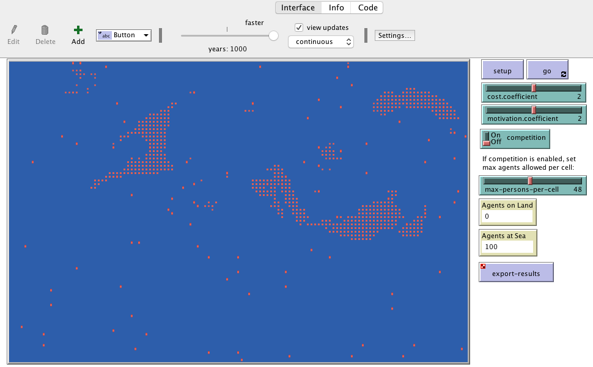

Figure 11: Preliminary Run over LSL

```
#cost surface
require(gdistance)

#cost motivation
LSLcost <- (raster3LSL - raster4LSL)
plot(LSLcost, main="Low Sea Level Cost Surface")
```

Code Chunk 11: Cost Surface for LSL Face Validation (R)

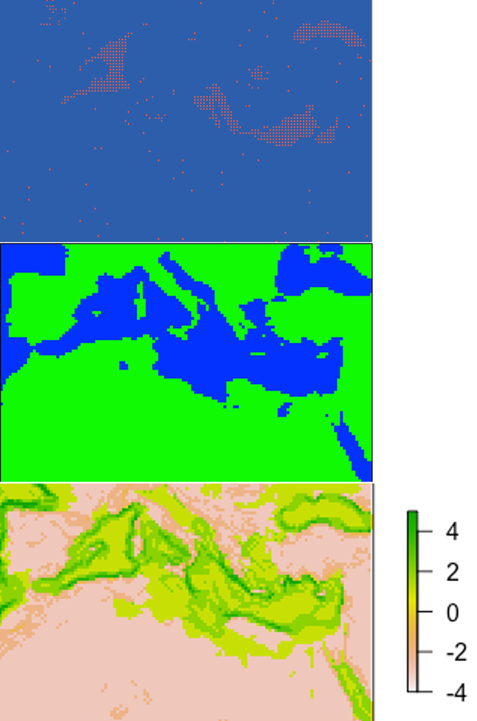

Figure 12: A side-by-side comparison of LSL Preliminary Results, Base Map, and LSL Cost Surface

These preliminary results can be used to understand the implications of the revisionist conceptual model. In this model, the sea itself is not a barrier to travel. Instead this model shows where areas of high slope and high wind may have been a barrier to travel.

## 4.2. Possible Variations

A model does not need to include every variable that exists in the real system. It only needs to capture the core of the system, the driver(s) that really make it work. Because they were not essential to this model, greater complexity and more variables were not added. However future researchers might be interested in exploring different routes in related models. This section provides guidance for adding new variables and greater complexity to this model.

### 4.2.1. Adding More Complex Data

Future versions of this model might use directional variables such as aspect in addition to slope, or wind direction as well as wind speed. They might substitute data with finer spatial and temporal resolutions. In this model, rook case (4 proximal cells) was used for spatial analysis and NetLogo decision-making. Future work might use queen case (8 proximal cells). The cells in this agent-based model are aggregated to 34 km X 34 km but if a future model is able to be run on a computer with more RAM or a version of NetLogo not yet released, these cells might be set smaller. Computing power limited this first version of the model but it might not necessarily limit future versions.

While the archaeological record of this activity is too incomplete and damaged to help systematically validate this model, the fossil record might be able to help. As described in Section 1.2, humans might have been pursuing better flora and fauna as well as better climates when they migrated. Fossils of plants and animals they would have relied upon are a relevant dataset that could help validate future version of this model.

### 4.2.2. Adding Other Variables

In this version of the model, vegetation, in the form of the Aeolian dust proxy, is the main driver. This is justified by our current understanding of the importance of vegetation in Pleistocene migration (described in Section 1.2). Nevertheless, there are still other variables that affect sea crossings and these might be the focus of alternate versions of this model. One of those variables is coastline density. As McEvedy (2002) suggests, denser, more complex coastlines could have increased the interaction between humans and the sea, creating littoral communities and even hotspots for early sea crossings (Broodbank 2013). Conversely, there would be fewer sea crossings where the coastline is longer and straighter. This could help explain why there is more evidence of early sea crossings in the Aegean compared to the rest of the Mediterranean. In the current version of the model, agents only cross the sea where local cost from slope is greater than local cost from wind and vegetation motivation is high enough. Instead, maybe agents should be slightly more likely to cross the sea when they are in a region of relatively dense coastline. The R code that can be used to calculate coastline density is shown below in Code Chunk 12.

```
#coastline draw
raster0.coast <- raster("~/Desktop/seacrossings/raster0")
projection(raster0.coast) <- "+proj=wintri"
summary(raster0.coast)

coast.pol <- rasterToPolygons(raster0.coast, fun=function(raster0.coast){raster0.coast = 0})

fun=function(x){x>3 & x<6}

m.coast <- c(-5300, -1, 0, -1, 1, 1, 1, 4200, 0)
rclmat.coast <- matrix(m.coast, ncol =3, byrow= TRUE)
classified.coast<- reclassify(raster0.coast, rclmat.coast)

hist(classified.coast)
breakpoints.coast <- c(-1, 0, 1)
colors.coast <- c("white", "black")
plot(classified.coast, breaks=breakpoints.coast, col=colors.coast)


#coastline density
m.coast <- c(-5300, -1, NA, -1, 1, 1, 1, 4200, NA)
rclmat.coast <- matrix(m.coast, ncol =3, byrow= TRUE)
classified.coast<- reclassify(raster0.coast, rclmat.coast)
```

Code Chunk 12: Coastline Density (R)

Another variable that might be considered is visibility, especially shore visibility. Seafaring where the shore is not visible would have to involve greater navigation and planning, or else very lucky drifting. This variable was not included in this version of the model because the places where environments created opportunities for sea crossings needed to be represented first before the varying cognitive abilities of agents could be added. However, this model could be adapted to include shore visibility. At the time of this writing, R does not have any viewshed or visibility functions that do not rely on proprietary software. To keep this process open source and easily repeated for large datasets, a work around, shown in Code Chunk 13, was developed. Here the visibility of land from sea is calculated as a function of distance.

```
#visibility

require(raster)
require(gdistance)
require(RColorBrewer)

#import & project base raster, using unaggregated version
raster0.na <- raster("~/Desktop/seacrossings/raster0")
projection(raster0.na) <- "+proj=wintri"

#sea values become NA
raster0.na[raster0.na <= 0] <- NA

#calculate distance for all NA cells (sea) to nearest non NA cell (land)
raster0.distance <- distance(raster0.na)
c <- brewer.pal(6, "Blues")
plot(raster0.distance, col= c)
```

Code Chunk 13: Visibility of Land from Sea (R)

Altering the decision-making horizon might offer the most interesting path for developing this model. If agents can look further ahead spatially and temporally, they might be able to make better decisions about where to move. Variables like visibility offer an indirect way to represent agent planning in an agent-based model. On the other hand, directly changing the decision horizons of agents allows this planning to be explicitly represented in the model. It would be important to see how giving agents the ability to plan further might affect the amount of agent presence on sea cells.

From the perspective of Mediterranean archaeologists and anthropologists in general, this model’s decision-making horizon can be an excellent tool for testing theories about voyaging (or drifting) and Neanderthal cognitive abilities. The first iteration of this model deliberately sidesteps this debate to focus more on environmental opportunities. However, it could be further adapted to weigh in on more abstract questions around evolutionary timelines.

### 4.2.3. Variation in the Agents Themselves

Agent-based modeling offers a powerful tool for exploring how individual decisions can produce the patterns that define a system. In this version of the model, all the individuals make decisions the same way. Yet it might be worth introducing some variation in the decision-making schemes of agents in future versions of this model. Additional data would be needed so that the number of agents in the system and the range of starting points could be more closely represented. Agents could then be programed to group together and cooperate. If bigger, more sea-worthy vessels existed in the Middle to Late Pleistocene, it may have taken more than one person to build and sail them. Agents might also be given a range of decision-making horizons or some could be made to be more risk averse while others could be less risk averse. This modeling effort only begins to explore what an agent-based model of coastal migration during this time could do. Agent-based modeling can offer insights into the gaps in the archaeological record that could previously have only been filled with speculation from competing theories.